# Homework Assignment 1

DA 4 - CEU 2018

Kristof Menyhert

2018-02-10

Load the packages and set the theme to bw:

```r
library(data.table)
library(caret)
library(ggplot2)
library(knitr)
library(stargazer)
library(rattle)
library(randomForest)
library(rpart)
library(rpart.plot)


theme_set(theme_bw()) #globally set ggplot theme to black & white
```

Load the dataset:

```r
data <- fread("C:/Users/Chronos/OneDrive - Central European University/R/da4_hw1/airbnb_london_cleaned.csv")
```

Filter for extreme values in price:

This is an arbitrary choice, but helps the prediction a lot from my point of view:

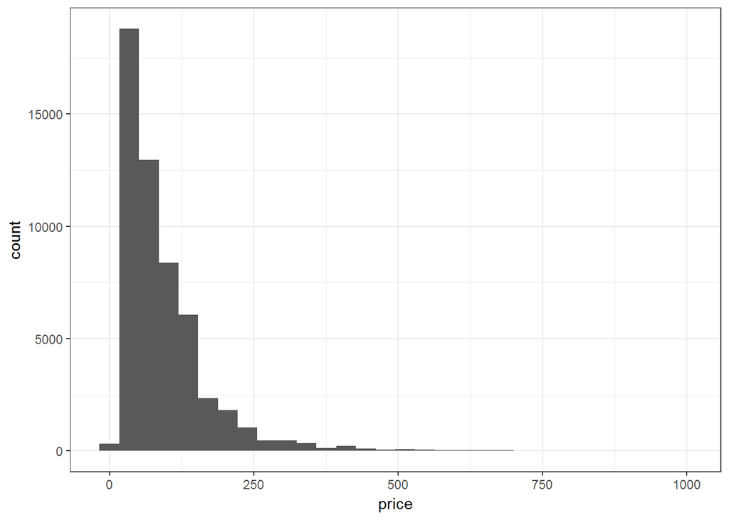

```r
data$price <- as.numeric(data$price)
ggplot(data, aes(price)) + geom_histogram()
```

```r
#based on the graph above I choose 600$ to the maximum price:
data <- data[price < 600] # I lost around 300 observations
```

Randomly pick a neighborhood with at least 1000 observations:

```r
unique_neigh <- data[, .(observations = .N), by = neighbourhood_cleansed] # count how many observations are there for one neigbourhood
unique_neigh <- unique_neigh[observations > 1000] #drop neighbourhood with less then 1000 observations

neighbourhood_obs <- unique_neigh$neighbourhood #vector with all the neighbourhood

set.seed(5452)
random_neighbourhood <- sample(neighbourhood_obs, 1, replace=TRUE)
```

In this case I randomly selected the following neighborhood:

```r
random_neighbourhood
```

```
## [1] "Southwark"
```

Filter for the random neighborhood:

```r
filtered_data <- data[neighbourhood_cleansed == random_neighbourhood]
```

## I. TASK: MODELING WITH THE RANDOMLY SELECTED NEIGHBOURHOOD:

At first, we need to decide whether we are going to predict the price or the log_price:

Histogram of price:

```r
filtered_data$price <- as.numeric(filtered_data$price)
summary(filtered_data$price)
```

```
##    Min. 1st Qu.  Median    Mean 3rd Qu.    Max.
##   10.00   42.00   68.00   84.71  105.00  567.00
```

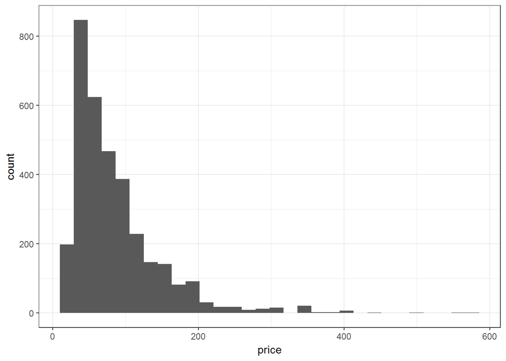

```r
filtered_data <- filtered_data[price>0] #drop NAs

ggplot(filtered_data, aes(price)) + geom_histogram()
```

I think predicting log_price make more sense, since the normal price variable is not normally distributed. Therefore I create the log_price variable:

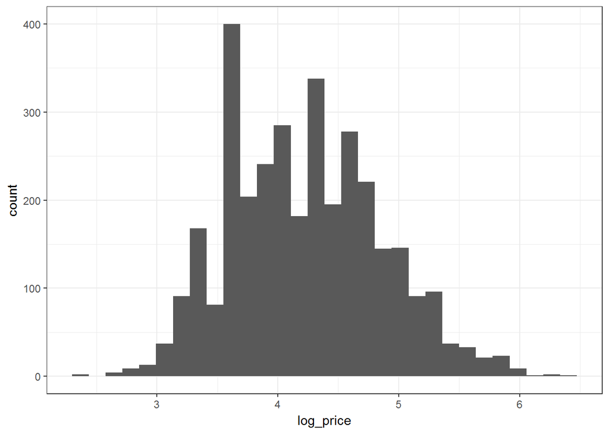

```r
filtered_data[, log_price := log(price)]
ggplot(filtered_data, aes(log_price)) + geom_histogram()
```

It looks like that log_price distribution is closer to normal, therefore for my further analysis I use log_price.

Then I split the data to train and test sets:

```r
cut <- createDataPartition(y = filtered_data$price, times = 1, p = 0.7, list = FALSE)

filtered_data_train <- filtered_data[cut, ]

filtered_data_test <- filtered_data[-cut, ]

# check the cut
length(filtered_data$price) == (length(filtered_data_train$price) + length(filtered_data_test$price))
```

```
## [1] TRUE
```

#### a) Show 4 different linear models, arguing for choices (#4 should be most complex)

**1st linear model: Log_Price vs. Accommodates**

Some of the variables are characters and not numbers as they should be I have to manually transform them to numeric values:

```r
filtered_data_train$accommodates <- as.numeric(filtered_data_train$accommodates)
filtered_data_train <- filtered_data_train[accommodates>0] #drop NAs

#do the same for test data:
filtered_data_test$accommodates <- as.numeric(filtered_data_test$accommodates)
filtered_data_test <- filtered_data_test[accommodates>0]
```

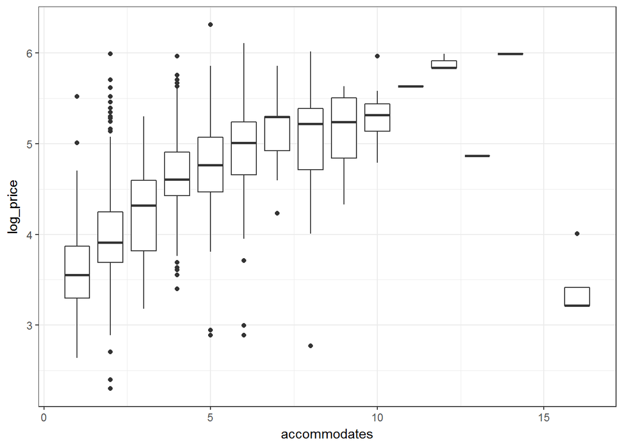

```r
ggplot(filtered_data_train, aes(x=accommodates, y=log_price)) + geom_boxplot((aes(group = cut_width(accommodates, 1))))
```

Seems like if an accommodation can host higher number of guests the price is rising on average, but not linear. Therefore I use the poly function with a quadratic term.

In the 1st model I use only 1 variable.

```r
#without CV:
lm_model1 <- train(log_price ~ poly(accommodates,2),
                  data = filtered_data_train,
                  method = "lm",
                  trControl = trainControl(method = "none"))

#with CV:
lm_model1_cv <- train(log_price ~ poly(accommodates,2),
                  data = filtered_data_train,
                  method = "lm",
                  trControl = trainControl(method = "cv", number = 10))

summary(lm_model1)
```

```
##
## Call:
## lm(formula = .outcome ~ ., data = dat)
##
## Residuals:
##      Min       1Q   Median       3Q      Max
## -2.41670 -0.29979  0.00087  0.27328  2.00280
##
## Coefficients:
##                           Estimate Std. Error t value Pr(>|t|)
## (Intercept)               4.235968   0.009401  450.58   <2e-16 ***
## `poly(accommodates, 2)1` 18.953054   0.455733   41.59   <2e-16 ***
## `poly(accommodates, 2)2` -8.933464   0.455733  -19.60   <2e-16 ***
## ---
## Signif. codes:  0 '***' 0.001 '**' 0.01 '*' 0.05 '.' 0.1 ' ' 1
##
## Residual standard error: 0.4557 on 2347 degrees of freedom
## Multiple R-squared:  0.4739, Adjusted R-squared:  0.4734
## F-statistic:  1057 on 2 and 2347 DF,  p-value: < 2.2e-16
```

```r
lm_model1_cv
```

```
## Linear Regression
##
## 2350 samples
##    1 predictor
##
## No pre-processing
## Resampling: Cross-Validated (10 fold)
## Summary of sample sizes: 2115, 2115, 2114, 2114, 2116, 2116, ...
## Resampling results:
##
##   RMSE      Rsquared   MAE
##   0.455787  0.4735184  0.3539257
##
## Tuning parameter 'intercept' was held constant at a value of TRUE
```

If we look at the Rsquared they are close to each other. Using CV in this case has little effect. I think it is because we have 1000+ observations. On big datasets CV is not as important as on small ones.

**2nd linear model: Log_Price vs. Accommodates + Room_type**

I extend the model with 1 more variable: Roomy_type.

Log_price vs. Room type:

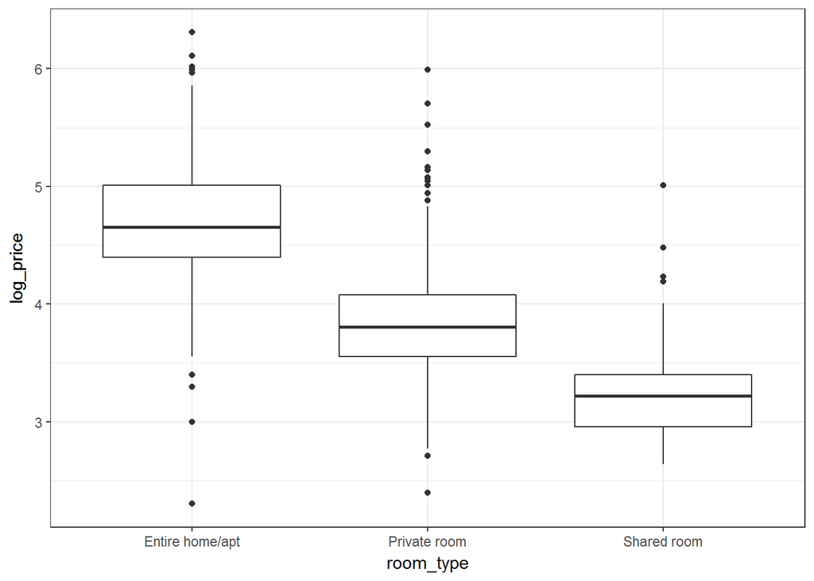

```r
ggplot(filtered_data_train, aes(x=room_type, y=log_price)) + geom_boxplot()
```

As we can see on the graph above, room_type has a lots of effect on price.

Room_type is a factor variable, therefore I use in my model as a factor:

```r
# Without CV:
lm_model2 <- train(log_price ~ poly(accommodates,2) + as.factor(room_type),
                  data = filtered_data_train,
                  method = "lm",
                  trControl = trainControl(method = "none"))

# With CV:
lm_model2_cv <- train(log_price ~ poly(accommodates,2) + as.factor(room_type),
                  data = filtered_data_train,
                  method = "lm",
                  trControl = trainControl(method = "cv", number = 10))

summary(lm_model2)
```

```
##
## Call:
## lm(formula = .outcome ~ ., data = dat)
##
## Residuals:
##     Min      1Q  Median      3Q     Max
## -2.1253 -0.2535 -0.0268  0.2362  2.1580
##
## Coefficients:
##                                    Estimate Std. Error t value Pr(>|t|)
## (Intercept)                         4.56123    0.01394  327.21  < 2e-16
## `poly(accommodates, 2)1`           10.62060    0.49069   21.64  < 2e-16
## `poly(accommodates, 2)2`           -3.48390    0.43169   -8.07 1.11e-15
## `as.factor(room_type)Private room` -0.59445    0.02151  -27.64  < 2e-16
## `as.factor(room_type)Shared room`  -1.09632    0.06197  -17.69  < 2e-16
##
## (Intercept)                        ***
## `poly(accommodates, 2)1`           ***
## `poly(accommodates, 2)2`           ***
## `as.factor(room_type)Private room` ***
## `as.factor(room_type)Shared room`  ***
## ---
## Signif. codes:  0 '***' 0.001 '**' 0.01 '*' 0.05 '.' 0.1 ' ' 1
##
## Residual standard error: 0.3894 on 2345 degrees of freedom
## Multiple R-squared:  0.6163, Adjusted R-squared:  0.6156
## F-statistic: 941.5 on 4 and 2345 DF,  p-value: < 2.2e-16
```

```r
lm_model2_cv$finalModel
```

```
##
## Call:
## lm(formula = .outcome ~ ., data = dat)
##
## Coefficients:
##                        (Intercept)            `poly(accommodates, 2)1`
##                             4.5612                             10.6206
##           `poly(accommodates, 2)2`  `as.factor(room_type)Private room`
##                            -3.4839                             -0.5945
##  `as.factor(room_type)Shared room`
##                            -1.0963
```

R-squared improved a bit.

**3rd linear model: Log_Price vs. Accommodates + Room_type + Location rating**

My basic thought was the following: one of the biggest factor concerning price of an accommodation is the location.

There are a lots of missing values, but I think we can use it for something:

- I assigned “10” for accommodations with location score above 9.
- I assigned “Under_10” for accommodations with scores not above 9.
- I assigned “Not included” for missing values.

See the coding below:

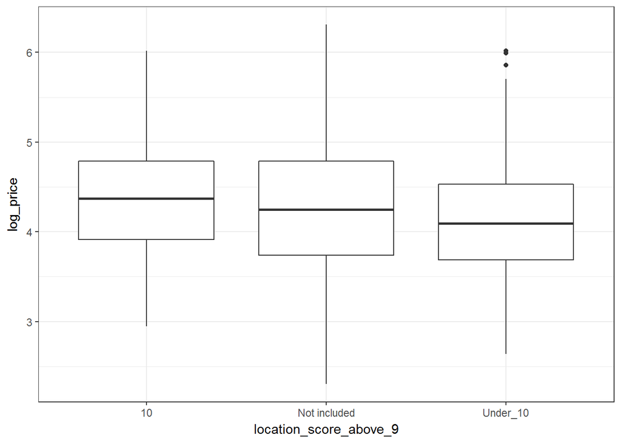

```r
filtered_data_train$review_scores_location <- as.numeric(filtered_data_train$review_scores_location)

filtered_data_train[, location_score_above_9 := ifelse(review_scores_location > 9, "10", "Under_10")]

filtered_data_train[, location_score_above_9 := ifelse(is.na(location_score_above_9), "Not included", location_score_above_9)]

ggplot(filtered_data_train, aes(x=location_score_above_9, y=log_price)) + geom_boxplot()
```

```r
#do the same for test data:
filtered_data_test$review_scores_location <- as.numeric(filtered_data_test$review_scores_location)

filtered_data_test[, location_score_above_9 := ifelse(review_scores_location > 9, "10", "Under_10")]

filtered_data_test[, location_score_above_9 := ifelse(is.na(location_score_above_9), "Not included", location_score_above_9)]
```

Actually it turned out that this variable does not have a lots of effect to the prices:

```r
#without CV
lm_model3 <- train(log_price ~ poly(accommodates,2) + as.factor(room_type) + as.factor(location_score_above_9),
                  data = filtered_data_train,
                  method = "lm",
                  trControl = trainControl(method = "none"))

#with CV
lm_model3_cv <- train(log_price ~ poly(accommodates,2) + as.factor(room_type) + as.factor(location_score_above_9),
                  data = filtered_data_train,
                  method = "lm",
                  trControl = trainControl(method = "cv", number = 10))
```

```r
summary(lm_model3)
```

```
##
## Call:
## lm(formula = .outcome ~ ., data = dat)
##
## Residuals:
##      Min       1Q   Median       3Q      Max
## -2.19321 -0.23771 -0.02414  0.20374  2.07019
##
## Coefficients:
##                                                  Estimate Std. Error
## (Intercept)                                      4.627233   0.017320
## `poly(accommodates, 2)1`                        11.071887   0.477449
## `poly(accommodates, 2)2`                        -3.737407   0.419664
## `as.factor(room_type)Private room`              -0.574526   0.020917
## `as.factor(room_type)Shared room`               -1.046463   0.060225
## `as.factor(location_score_above_9)Not included`  0.007918   0.020485
## `as.factor(location_score_above_9)Under_10`     -0.191899   0.018447
##                                                 t value Pr(>|t|)
## (Intercept)                                     267.155   <2e-16 ***
## `poly(accommodates, 2)1`                         23.190   <2e-16 ***
## `poly(accommodates, 2)2`                         -8.906   <2e-16 ***
## `as.factor(room_type)Private room`              -27.467   <2e-16 ***
## `as.factor(room_type)Shared room`               -17.376   <2e-16 ***
## `as.factor(location_score_above_9)Not included`   0.387    0.699
## `as.factor(location_score_above_9)Under_10`     -10.403   <2e-16 ***
## ---
## Signif. codes:  0 '***' 0.001 '**' 0.01 '*' 0.05 '.' 0.1 ' ' 1
##
## Residual standard error: 0.3775 on 2343 degrees of freedom
## Multiple R-squared:  0.6396, Adjusted R-squared:  0.6387
## F-statistic:   693 on 6 and 2343 DF,  p-value: < 2.2e-16
```

R-squared improved a bit again.

**4rd linear model: Log_Price vs. Accommodates + Room_type + Location rating + Security_deposit + Bathrooms etc.**

I extended my model with some other variables as well.

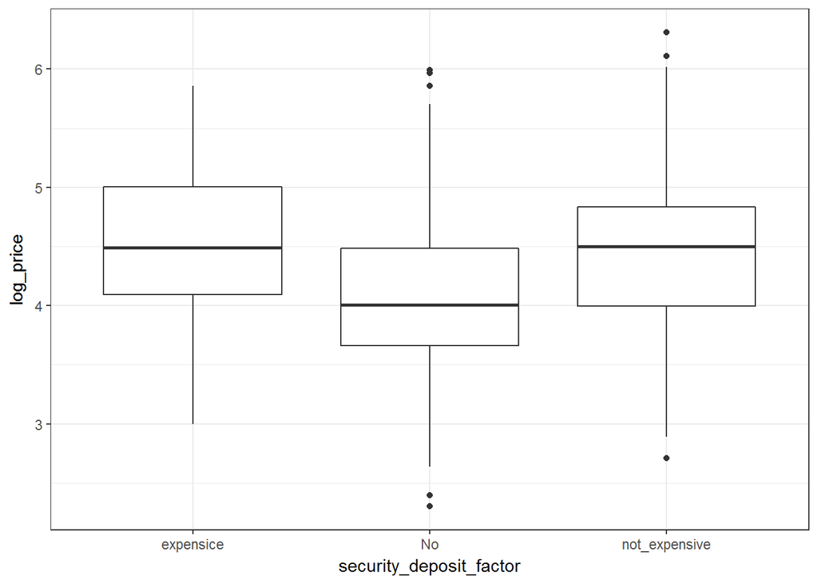

```r
filtered_data_train$security_deposit <- as.numeric(filtered_data_train$security_deposit)
filtered_data_train[, security_deposit_factor := ifelse(is.na(security_deposit), "No", ifelse(security_deposit > 500, "expensice", "not_expensive"))]

ggplot(filtered_data_train, aes(x=security_deposit_factor, y=log_price)) + geom_boxplot()
```

```r
# do the same for test set:
filtered_data_test$security_deposit <- as.numeric(filtered_data_test$security_deposit)
filtered_data_test[, security_deposit_factor := ifelse(is.na(security_deposit), "No", ifelse(security_deposit > 500, "expensice", "not_expensive"))]
```

Other variables correction:

```r
filtered_data_train$host_is_superhost <- as.numeric(filtered_data_train$host_is_superhost)
filtered_data_train[, host_is_superhost :=ifelse(host_is_superhost == 1, 1, 0)]
filtered_data_train$host_is_superhost <- as.factor(filtered_data_train$host_is_superhost)

filtered_data_train$bathrooms <- as.numeric(filtered_data_train$bathrooms)

filtered_data_train <- filtered_data_train[!is.na(bathrooms)]

#do the same for test set:
filtered_data_test$host_is_superhost <- as.numeric(filtered_data_test$host_is_superhost)
filtered_data_test[, host_is_superhost :=ifelse(host_is_superhost == 1, 1, 0)]
filtered_data_test$host_is_superhost <- as.factor(filtered_data_test$host_is_superhost)

filtered_data_test$bathrooms <- as.numeric(filtered_data_test$bathrooms)

filtered_data_test <- filtered_data_test[!is.na(bathrooms)]
```

```r
lm_model4 <- train(log_price ~ poly(accommodates,2) + as.factor(room_type) + as.factor(location_score_above_9) + as.factor(security_deposit_factor) +  host_is_superhost+bathrooms,
                  data = filtered_data_train,
                  method = "lm",
                  trControl = trainControl(method = "none"))

lm_model4_cv <- train(log_price ~ poly(accommodates,2) + as.factor(room_type) + as.factor(location_score_above_9) + as.factor(security_deposit_factor) + host_is_superhost + bathrooms,
                  data = filtered_data_train,
                  method = "lm",
                  trControl = trainControl(method = "cv", number = 10))
```

```r
summary(lm_model4)
```

```
##
## Call:
## lm(formula = .outcome ~ ., data = dat)
##
## Residuals:
##      Min       1Q   Median       3Q      Max
## -2.14553 -0.23438 -0.01256  0.22014  2.12467
##
## Coefficients:
##                                                   Estimate Std. Error
## (Intercept)                                        4.54540    0.08447
## `poly(accommodates, 2)1`                           9.31491    0.51076
## `poly(accommodates, 2)2`                          -3.71705    0.41092
## `as.factor(room_type)Private room`                -0.58018    0.02090
## `as.factor(room_type)Shared room`                 -1.05060    0.05989
## `as.factor(location_score_above_9)Not included`    0.02149    0.02047
## `as.factor(location_score_above_9)Under_10`       -0.17738    0.01810
## `as.factor(security_deposit_factor)No`            -0.15509    0.08130
## `as.factor(security_deposit_factor)not_expensive` -0.09112    0.08135
## host_is_superhost1                                 0.11467    0.02640
## bathrooms                                          0.15474    0.01871
##                                                   t value Pr(>|t|)
## (Intercept)                                        53.809  < 2e-16 ***
## `poly(accommodates, 2)1`                           18.237  < 2e-16 ***
## `poly(accommodates, 2)2`                           -9.046  < 2e-16 ***
## `as.factor(room_type)Private room`                -27.762  < 2e-16 ***
## `as.factor(room_type)Shared room`                 -17.542  < 2e-16 ***
## `as.factor(location_score_above_9)Not included`     1.050   0.2937
## `as.factor(location_score_above_9)Under_10`        -9.797  < 2e-16 ***
## `as.factor(security_deposit_factor)No`             -1.908   0.0565 .
## `as.factor(security_deposit_factor)not_expensive`  -1.120   0.2628
## host_is_superhost1                                  4.343 1.46e-05 ***
## bathrooms                                           8.271  < 2e-16 ***
## ---
## Signif. codes:  0 '***' 0.001 '**' 0.01 '*' 0.05 '.' 0.1 ' ' 1
##
## Residual standard error: 0.3687 on 2327 degrees of freedom
## Multiple R-squared:  0.657,  Adjusted R-squared:  0.6555
## F-statistic: 445.7 on 10 and 2327 DF,  p-value: < 2.2e-16
```

#### LASSO on the 4th model:

For my 5th model I used LASSO on my previous (4th) model:

```r
set.seed(123)

#Without CV. Only wiht 1 lamda parameter:
lm_model_lasso <- train(log_price ~ poly(accommodates,2) + as.factor(room_type) + as.factor(location_score_above_9) + as.factor(security_deposit_factor) + host_is_superhost + bathrooms,
                  data = filtered_data_train,
                  method = "glmnet",
                  trControl = trainControl(method = "none"),
                  #preProcess = c("center", "scale"),
                  tuneGrid = expand.grid("alpha" = c(1),"lambda" = c(0.1)))

#with CV. With 4 lambda parameter:
lm_model_lasso_cv <- train(log_price ~ poly(accommodates,2) + as.factor(room_type) + as.factor(location_score_above_9) + as.factor(security_deposit_factor) + host_is_superhost + bathrooms,
                  data = filtered_data_train,
                  method = "glmnet",
                  trControl = trainControl(method = "cv", number = 10),
                  #preProcess = c("center", "scale"),
                  tuneGrid = expand.grid("alpha" = c(1),"lambda" = c(0.1, 0.01, 0.001, 0.0001)))

lm_model_lasso_cv
```

```
## glmnet
##
## 2338 samples
##    6 predictor
##
## No pre-processing
## Resampling: Cross-Validated (10 fold)
## Summary of sample sizes: 2104, 2104, 2104, 2104, 2104, 2103, ...
## Resampling results across tuning parameters:
##
##   lambda  RMSE       Rsquared   MAE
##   1e-04   0.3688895  0.6561959  0.2802370
##   1e-03   0.3686753  0.6565592  0.2801650
##   1e-02   0.3691658  0.6562882  0.2812932
##   1e-01   0.4229692  0.5904330  0.3226194
##
## Tuning parameter 'alpha' was held constant at a value of 1
## RMSE was used to select the optimal model using the smallest value.
## The final values used for the model were alpha = 1 and lambda = 0.001.
```

## II. TASK: MODELING WITH THE FULL LONDON DATASET:

In the 2nd task I am doing the same as before just for the full London dataset, and also I add the neighborhood variable as factor to the regressions for controlling for the different neighborhood. 1st I do not do any interaction. At the end of the exercise I try to create a final model with interactions.

Create again the log_price variable for the full dataset.

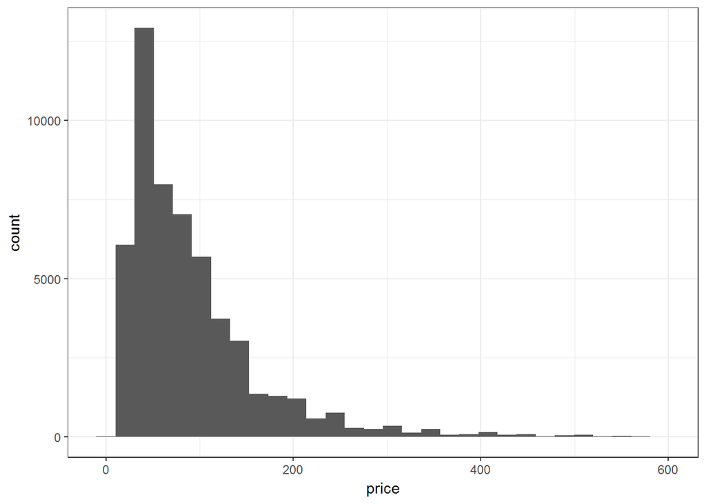

```r
data$price <- as.numeric(data$price)
data <- data[price > 0]

ggplot(data, aes(price)) + geom_histogram() #log normal dist
```

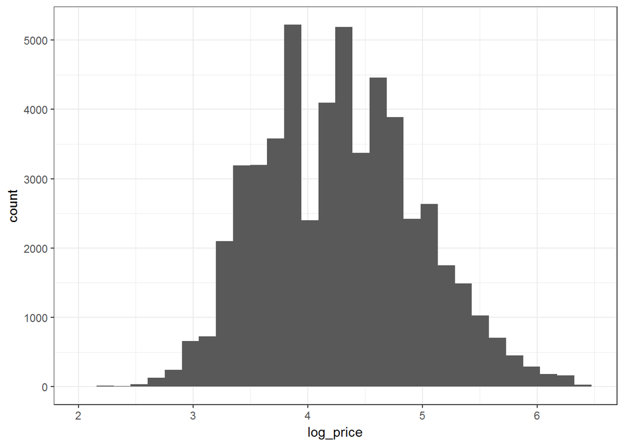

```r
data[, log_price := log(price)]

ggplot(data, aes(log_price)) + geom_histogram()
```

**This is why I add the neighborhoods to the model:**

Neighbors vs. price plot:

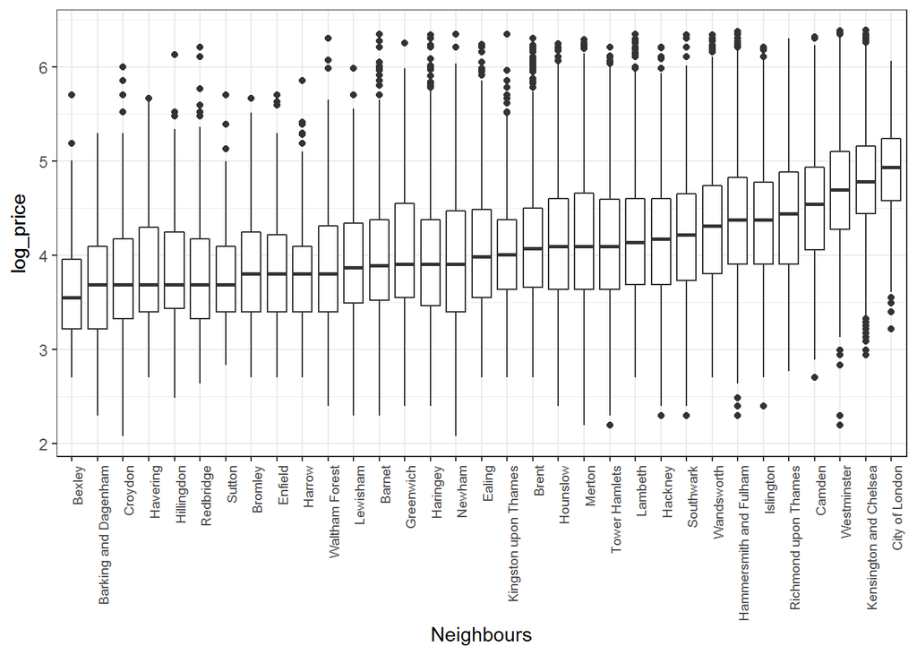

```r
ggplot(data, aes(reorder(as.factor(neighbourhood_cleansed), log_price, FUN=median),log_price)) + geom_boxplot() +  theme(axis.text.x = element_text(angle=90, hjust=1, size = 7)) + labs(x = "Neighbours")
```

City of London is the most expensive neighborhood.

**Next Steps are creating the same dummies as I used before and do some transformations in the data as before**

DO the transformations and any modification before spiting the data to train and test set:

For the accommodation variable:

```r
data$accommodates <- as.numeric(data$accommodates)
data <- data[accommodates>0] #drop NAs
```

Create review_scores factor:

```r
data$review_scores_location <- as.numeric(data$review_scores_location)

data[, location_score_above_9 := ifelse(review_scores_location > 9, "10", "Under_10")]

data[, location_score_above_9 := ifelse(is.na(location_score_above_9), "Not included", location_score_above_9)]
```

Fix security_deposit variable and create a factor from it:

```r
data$security_deposit <- as.numeric(data$security_deposit)
data[, security_deposit_factor := ifelse(is.na(security_deposit), "No", ifelse(security_deposit > 500, "expensice", "not_expensive"))]
```

Fix host_is_superhost and the bathrooms variable:

```r
data$host_is_superhost <- as.numeric(data$host_is_superhost)
data[, host_is_superhost :=ifelse(host_is_superhost == 1, 1, 0)]
data$host_is_superhost <- as.factor(data$host_is_superhost)

data <- data[!is.na(host_is_superhost)]

data$bathrooms <- as.numeric(data$bathrooms)

data <- data[!is.na(bathrooms)]
```

**Do the splitting:**

```r
cut <- createDataPartition(y = data$price, times = 1, p = 0.7, list = FALSE)

data_train <- data[cut, ]

data_test <- data[-cut, ]

# check the cut
length(data$price) == (length(data_train$price) + length(data_test$price))
```

```
## [1] TRUE
```

**1st linear model: Log_Price vs. Neighborhood + Accommodates**

See why:

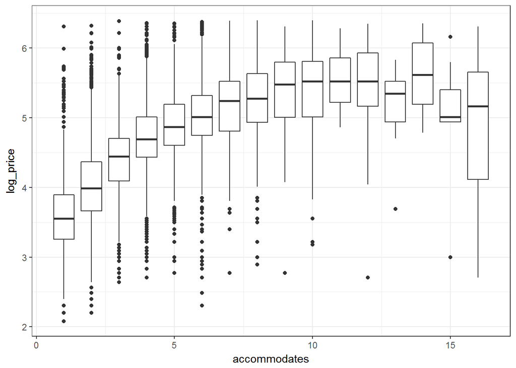

```r
ggplot(data_train, aes(x=accommodates, y=log_price)) + geom_boxplot((aes(group = cut_width(accommodates, 1))))
```

```r
# without CV
lm_model_full1 <- train(log_price ~ poly(accommodates,2) + as.factor(neighbourhood_cleansed),
                  data = data_train,
                  method = "lm",
                  trControl = trainControl(method = "none"))
# with CV
lm_model_full1_cv <- train(log_price ~ poly(accommodates,2) + as.factor(neighbourhood_cleansed),
                  data = data_train,
                  method = "lm",
                  trControl = trainControl(method = "cv", number = 10))
```

**2nd linear model: Log_Price vs. Neighborhood + Accommodates + Room_type**

Room_type is a factor variable, therefore I use in my model like a factor.

```r
# without CV
lm_model_full2 <- train(log_price ~ poly(accommodates,2) + as.factor(neighbourhood_cleansed) + as.factor(room_type),
                  data = data_train,
                  method = "lm",
                  trControl = trainControl(method = "none"))
# with CV
lm_model_full2_cv <- train(log_price ~ poly(accommodates,2) + as.factor(neighbourhood_cleansed) + as.factor(room_type),
                  data = data_train,
                  method = "lm",
                  trControl = trainControl(method = "cv", number = 10))
```

**3rd linear model: Log_Price vs. Accommodates + Room_type + Location rating**

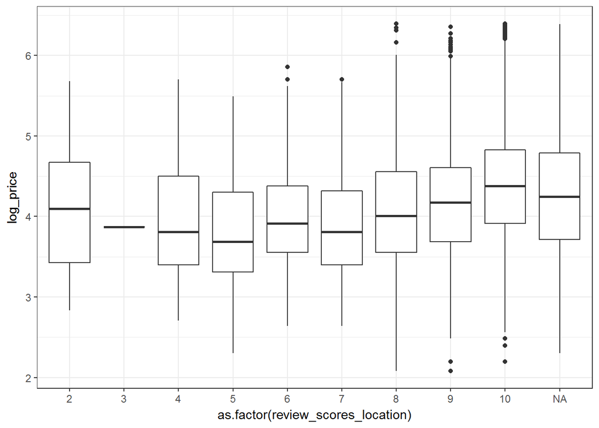

```r
ggplot(data_train, aes(x=as.factor(review_scores_location), y=log_price)) + geom_boxplot()
```

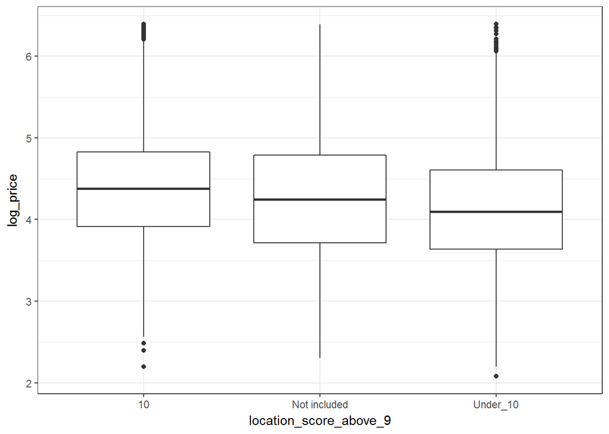

```r
ggplot(data_train, aes(x=location_score_above_9, y=log_price)) + geom_boxplot()
```

Not a very big effect but still, lets try including it in the model:

```r
# without CV
lm_model_full3 <- train(log_price ~ poly(accommodates,2) + as.factor(neighbourhood_cleansed) + as.factor(room_type) + as.factor(location_score_above_9),
                  data = data_train,
                  method = "lm",
                  trControl = trainControl(method = "none"))
# with CV
lm_model_full3_cv <- train(log_price ~ poly(accommodates,2) + as.factor(neighbourhood_cleansed) + as.factor(room_type) + as.factor(location_score_above_9),
                  data = data_train,
                  method = "lm",
                  trControl = trainControl(method = "cv", number = 10))
```

**4rd linear model: Log_Price vs. Neighborhood + Accommodates + Room_type + Location rating + Security_deposit + etc.**

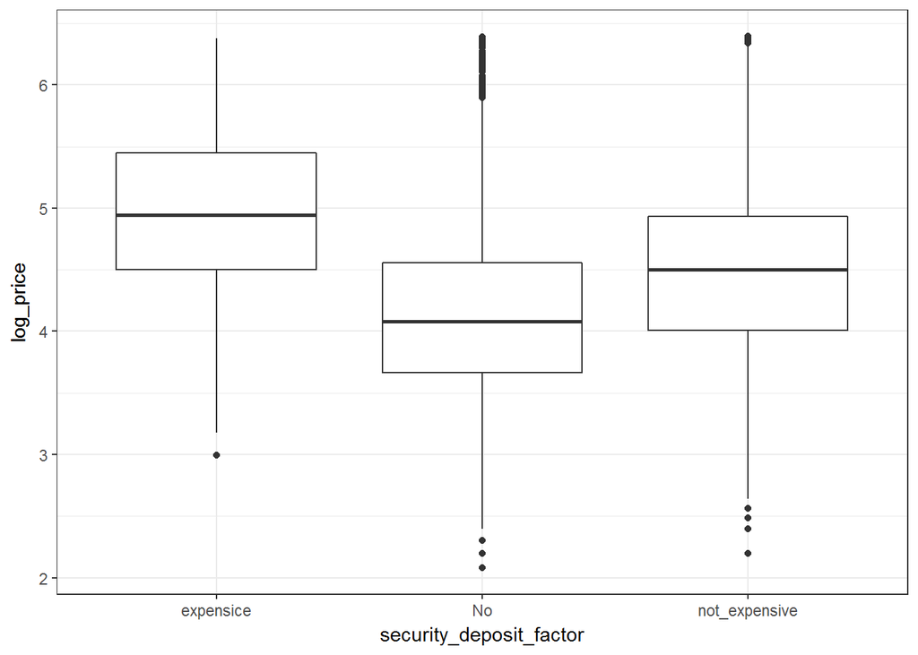

```r
ggplot(data, aes(x=security_deposit_factor, y=log_price)) + geom_boxplot()
```

```r
# without CV
lm_model_full4 <- train(log_price ~ poly(accommodates,2) + as.factor(neighbourhood_cleansed) + as.factor(room_type) + as.factor(location_score_above_9) + as.factor(security_deposit_factor) + bathrooms + as.factor(host_is_superhost),
                  data = data_train,
                  method = "lm",
                  trControl = trainControl(method = "none"))
# with CV
lm_model_full4_cv <- train(log_price ~ poly(accommodates,2) + as.factor(neighbourhood_cleansed) + as.factor(room_type) + as.factor(location_score_above_9) + as.factor(security_deposit_factor) + bathrooms + as.factor(host_is_superhost),
                  data = data_train,
                  method = "lm",
                  trControl = trainControl(method = "cv", number = 10))
```

#### LASSO on the 4th model:

```r
set.seed(123)
# without CV
lm_model_full_lasso <- train(log_price ~ poly(accommodates,2) + as.factor(neighbourhood_cleansed) + as.factor(room_type) + as.factor(location_score_above_9) + as.factor(security_deposit_factor) + bathrooms + as.factor(host_is_superhost),
                  data = data_train,
                  method = "glmnet",
                  trControl = trainControl(method = "none"),
                  #preProcess = c("center", "scale"),
                  tuneGrid = expand.grid("alpha" = c(1),"lambda" = c(0.1)))

# with CV
lm_model_full_lasso_cv <- train(log_price ~ poly(accommodates,2) + as.factor(neighbourhood_cleansed) + as.factor(room_type) + as.factor(location_score_above_9) + as.factor(security_deposit_factor) + bathrooms + as.factor(host_is_superhost),
                  data = data_train,
                  method = "glmnet",
                  trControl = trainControl(method = "cv", number = 10),
                  #preProcess = c("center", "scale"),
                  tuneGrid = expand.grid("alpha" = c(1),"lambda" = c(0.1, 0.01, 0.001, 0.0001)))

lm_model_full_lasso_cv
```

```
## glmnet
##
## 37378 samples
##     7 predictor
##
## No pre-processing
## Resampling: Cross-Validated (10 fold)
## Summary of sample sizes: 33640, 33639, 33640, 33641, 33640, 33640, ...
## Resampling results across tuning parameters:
##
##   lambda  RMSE       Rsquared   MAE
##   1e-04   0.3745476  0.6983413  0.2882459
##   1e-03   0.3749021  0.6977847  0.2885487
##   1e-02   0.3793911  0.6915841  0.2925267
##   1e-01   0.4513201  0.5934094  0.3488626
##
## Tuning parameter 'alpha' was held constant at a value of 1
## RMSE was used to select the optimal model using the smallest value.
## The final values used for the model were alpha = 1 and lambda = 1e-04.
```

## CALCULATE RMSE FOR ALL THE MODELS ON THE TEST SET:

Now I have all my models:

- 5 model for only 1 neighborhood without cross validation
- 5 model for only 1 neighborhood with 10 fold CV
- 5 model for London without cross validation
- 5 model for London with 10 fold CV

Also, I have:

- 1 training and 1 test set for only 1 neighbor
- 1 training and 1 test set for entire London

**Calculate RMSE**

Define RMSE:

```r
#definte RMSE:
RMSE <- function(x, true_x) sqrt(mean((x - true_x)^2))
```

**Calculate the predicted values on the test set:**

**On the filtered data (for the given neighborhood):**

```r
# On the filtered data:
# W/O CV:
filtered_data_test$predicted_log_price_model1 <- predict.train(lm_model1, newdata = filtered_data_test)
filtered_data_test$predicted_log_price_model2 <- predict.train(lm_model2, newdata = filtered_data_test)
filtered_data_test$predicted_log_price_model3 <- predict.train(lm_model3, newdata = filtered_data_test)
filtered_data_test$predicted_log_price_model4 <- predict.train(lm_model4, newdata = filtered_data_test)
filtered_data_test$predicted_log_price_model5 <- predict.train(lm_model_lasso, newdata = filtered_data_test)
#With CV:
filtered_data_test$predicted_log_price_model1_cv <- predict.train(lm_model1_cv, newdata = filtered_data_test)
filtered_data_test$predicted_log_price_model2_cv <- predict.train(lm_model2_cv, newdata = filtered_data_test)
filtered_data_test$predicted_log_price_model3_cv <- predict.train(lm_model3_cv, newdata = filtered_data_test)
filtered_data_test$predicted_log_price_model4_cv <- predict.train(lm_model4_cv, newdata = filtered_data_test)
filtered_data_test$predicted_log_price_model5_cv <- predict.train(lm_model_lasso_cv, newdata = filtered_data_test)
# RMSE W/O CV:
model1_RMSE <- RMSE(filtered_data_test$predicted_log_price_model1, filtered_data_test$log_price)
model2_RMSE <- RMSE(filtered_data_test$predicted_log_price_model2, filtered_data_test$log_price)
model3_RMSE <- RMSE(filtered_data_test$predicted_log_price_model3, filtered_data_test$log_price)
model4_RMSE <- RMSE(filtered_data_test$predicted_log_price_model4, filtered_data_test$log_price)
model5_RMSE <- RMSE(filtered_data_test$predicted_log_price_model5, filtered_data_test$log_price)
#RMSE with CV:
model1_RMSE_cv <- RMSE(filtered_data_test$predicted_log_price_model1_cv, filtered_data_test$log_price)
model2_RMSE_cv <- RMSE(filtered_data_test$predicted_log_price_model2_cv, filtered_data_test$log_price)
model3_RMSE_cv <- RMSE(filtered_data_test$predicted_log_price_model3_cv, filtered_data_test$log_price)
model4_RMSE_cv <- RMSE(filtered_data_test$predicted_log_price_model4_cv, filtered_data_test$log_price)
model5_RMSE_cv <- RMSE(filtered_data_test$predicted_log_price_model5_cv, filtered_data_test$log_price)
```

**RMSE of different models on the test set for a given neighborhood using log price**

```r
#Create a table:
table1 <- data.table(Models = c("model1", "model2", "model3", "model4", "model5_lasso"), RMSE_WITHOUT_CV = c(model1_RMSE, model2_RMSE, model3_RMSE, model4_RMSE, model5_RMSE), RMSE_WITH_CV = c(model1_RMSE_cv, model2_RMSE_cv, model3_RMSE_cv, model4_RMSE_cv, model5_RMSE_cv))

kable(table1, align = 'c', digits = 3)
```

| Models | RMSE_WITHOUT_CV | RMSE_WITH_CV |
| --- | --- | --- |
| model1 | 0.438 | 0.438 |
| model2 | 0.376 | 0.376 |
| model3 | 0.366 | 0.366 |
| model4 | 0.365 | 0.365 |
| model5_lasso | 0.408 | 0.365 |

**Full London:**

```r
#######
#ON the full dataset:
#W/O CV:
data_test$predicted_log_price_model1 <- predict.train(lm_model_full1, newdata = data_test)
data_test$predicted_log_price_model2 <- predict.train(lm_model_full2, newdata = data_test)
data_test$predicted_log_price_model3 <- predict.train(lm_model_full3, newdata = data_test)
data_test$predicted_log_price_model4 <- predict.train(lm_model_full4, newdata = data_test)
data_test$predicted_log_price_model5 <- predict.train(lm_model_full_lasso, newdata = data_test)
#With CV:
data_test$predicted_log_price_model1_cv <- predict.train(lm_model_full1_cv, newdata = data_test)
data_test$predicted_log_price_model2_cv <- predict.train(lm_model_full2_cv, newdata = data_test)
data_test$predicted_log_price_model3_cv <- predict.train(lm_model_full3_cv, newdata = data_test)
data_test$predicted_log_price_model4_cv <- predict.train(lm_model_full4_cv, newdata = data_test)
data_test$predicted_log_price_model5_cv <- predict.train(lm_model_full_lasso_cv, newdata = data_test)
# RMSE W/O CV:
model1_RMSE_full <- RMSE(data_test$predicted_log_price_model1, data_test$log_price)
model2_RMSE_full <- RMSE(data_test$predicted_log_price_model2, data_test$log_price)
model3_RMSE_full <- RMSE(data_test$predicted_log_price_model3, data_test$log_price)
model4_RMSE_full <- RMSE(data_test$predicted_log_price_model4, data_test$log_price)
model5_RMSE_full <- RMSE(data_test$predicted_log_price_model5, data_test$log_price)
#RMSE with CV:
model1_RMSE_cv_full <- RMSE(data_test$predicted_log_price_model1_cv, data_test$log_price)
model2_RMSE_cv_full <- RMSE(data_test$predicted_log_price_model2_cv, data_test$log_price)
model3_RMSE_cv_full <- RMSE(data_test$predicted_log_price_model3_cv, data_test$log_price)
model4_RMSE_cv_full <- RMSE(data_test$predicted_log_price_model4_cv, data_test$log_price)
model5_RMSE_cv_full <- RMSE(data_test$predicted_log_price_model5_cv, data_test$log_price)
```

**RMSE of different models on the test set for full London using log_price:**

```r
table2 <- data.table(Models = c("model1", "model2", "model3", "model4", "model5_lasso"), RMSE_WITHOUT_CV = c(model1_RMSE_full, model2_RMSE_full, model3_RMSE_full, model4_RMSE_full, model5_RMSE_cv_full), RMSE_WITH_CV = c(model1_RMSE_cv_full, model2_RMSE_cv_full, model3_RMSE_cv_full, model4_RMSE_cv_full, model5_RMSE_cv_full))

kable(table2, align = 'c', digits = 3)
```

| Models | RMSE_WITHOUT_CV | RMSE_WITH_CV |
| --- | --- | --- |
| model1 | 0.447 | 0.447 |
| model2 | 0.390 | 0.390 |
| model3 | 0.380 | 0.380 |
| model4 | 0.375 | 0.375 |
| model5_lasso | 0.375 | 0.375 |

**In the next part I try to convert my log prices back to level prices and try to evaluate my model on them:**

For simplification and due to the fact that CV models and not CV models are nearly identical in this problem set from now on I will use only the CV models for this exercise:

```r
# On the filtered data:
# With CV:
filtered_data_test$predicted_log_price_model1_real_values <- exp(filtered_data_test$predicted_log_price_model1_cv)
filtered_data_test$predicted_log_price_model2_real_values <- exp(filtered_data_test$predicted_log_price_model2_cv)
filtered_data_test$predicted_log_price_model3_real_values <- exp(filtered_data_test$predicted_log_price_model3_cv)
filtered_data_test$predicted_log_price_model4_real_values <- exp(filtered_data_test$predicted_log_price_model4_cv)
filtered_data_test$predicted_log_price_model5_real_values <- exp(filtered_data_test$predicted_log_price_model5_cv)

#Calculate RMSE:
RMSE1_real <- RMSE(filtered_data_test$predicted_log_price_model1_real_values, filtered_data_test$price)
RMSE2_real <- RMSE(filtered_data_test$predicted_log_price_model2_real_values, filtered_data_test$price)
RMSE3_real <- RMSE(filtered_data_test$predicted_log_price_model3_real_values, filtered_data_test$price)
RMSE4_real <- RMSE(filtered_data_test$predicted_log_price_model4_real_values, filtered_data_test$price)
RMSE5_real <- RMSE(filtered_data_test$predicted_log_price_model5_real_values, filtered_data_test$price)

#On the full Lonond data:
#With CV:
data_test$predicted_log_price_model1_real_values <- exp(data_test$predicted_log_price_model1_cv)
data_test$predicted_log_price_model2_real_values <- exp(data_test$predicted_log_price_model2_cv)
data_test$predicted_log_price_model3_real_values <- exp(data_test$predicted_log_price_model3_cv)
data_test$predicted_log_price_model4_real_values <- exp(data_test$predicted_log_price_model4_cv)
data_test$predicted_log_price_model5_real_values <- exp(data_test$predicted_log_price_model5_cv)

RMSE1_real_all <- RMSE(data_test$predicted_log_price_model1_real_values, data_test$price)
RMSE2_real_all <- RMSE(data_test$predicted_log_price_model2_real_values, data_test$price)
RMSE3_real_all <- RMSE(data_test$predicted_log_price_model3_real_values, data_test$price)
RMSE4_real_all <- RMSE(data_test$predicted_log_price_model4_real_values, data_test$price)
RMSE5_real_all <- RMSE(data_test$predicted_log_price_model5_real_values, data_test$price)
```

Create tables with the results:

```r
table3 <- data.table(Models = c("model1", "model2", "model3", "model4", "model5_lasso"), RMSE_WITH_CV = c(RMSE1_real, RMSE2_real, RMSE3_real, RMSE4_real, RMSE5_real))

table4 <- data.table(Models = c("model1", "model2", "model3", "model4", "model5_lasso"), RMSE_WITH_CV = c(RMSE1_real_all, RMSE2_real_all, RMSE3_real_all, RMSE4_real_all, RMSE5_real_all))
```

**RMSE of different models on the test set for a given neighborhood using level price:**

```r
kable(table3, align = 'c', digits = 3)
```

| Models | RMSE_WITH_CV |
| --- | --- |
| model1 | 45.261 |
| model2 | 42.543 |
| model3 | 41.209 |
| model4 | 40.292 |
| model5_lasso | 40.331 |

**RMSE of different models on the test set for a full London using level price:**

```r
kable(table4, align = 'c', digits = 3)
```

| Models | RMSE_WITH_CV |
| --- | --- |
| model1 | 52.078 |
| model2 | 49.267 |
| model3 | 48.184 |
| model4 | 46.208 |
| model5_lasso | 46.224 |

**BUT we can get better results by using a correction term when we converting back our log_price variable**

If we want to convert the log values to normal (level) values we should use the exp() function + a correction term:

Calculate correction term:

```r
#for the filtered data:
filtered_data_correctionterm <- sum((filtered_data_test$log_price - filtered_data_test$predicted_log_price_model1)^2/(length(filtered_data_test$log_price)-1))/2

full_data_correctionterm <- sum((data_test$log_price - data_test$predicted_log_price_model1)^2/(length(data_test$log_price)-1))/2

filtered_data_correctionterm
```

```
## [1] 0.09607796
```

```r
full_data_correctionterm
```

```
## [1] 0.09991183
```

Both of the correction terms are around 0.1. I know there are many of them (as many as many model I have) but now for simplification I will use 0.1 for all the correction terms for all models.

```r
# On the filtered data:
# With CV:
filtered_data_test$predicted_log_price_model1_real_values_correction <- exp(filtered_data_test$predicted_log_price_model1_cv + 0.10)
filtered_data_test$predicted_log_price_model2_real_values_correction <- exp(filtered_data_test$predicted_log_price_model2_cv + 0.10)
filtered_data_test$predicted_log_price_model3_real_values_correction <- exp(filtered_data_test$predicted_log_price_model3_cv + 0.10)
filtered_data_test$predicted_log_price_model4_real_values_correction <- exp(filtered_data_test$predicted_log_price_model4_cv + 0.10)
filtered_data_test$predicted_log_price_model5_real_values_correction <- exp(filtered_data_test$predicted_log_price_model5_cv + 0.10)

RMSE1_real_correction <- RMSE(filtered_data_test$predicted_log_price_model1_real_values_correction, filtered_data_test$price)
RMSE2_real_correction <- RMSE(filtered_data_test$predicted_log_price_model2_real_values_correction, filtered_data_test$price)
RMSE3_real_correction <- RMSE(filtered_data_test$predicted_log_price_model3_real_values_correction, filtered_data_test$price)
RMSE4_real_correction <- RMSE(filtered_data_test$predicted_log_price_model4_real_values_correction, filtered_data_test$price)
RMSE5_real_correction <- RMSE(filtered_data_test$predicted_log_price_model5_real_values_correction, filtered_data_test$price)

#On the full Lonond data:
#With CV:
data_test$predicted_log_price_model1_real_values_correction <- exp(data_test$predicted_log_price_model1_cv + 0.10)
data_test$predicted_log_price_model2_real_values_correction <- exp(data_test$predicted_log_price_model2_cv + 0.10)
data_test$predicted_log_price_model3_real_values_correction <- exp(data_test$predicted_log_price_model3_cv + 0.10)
data_test$predicted_log_price_model4_real_values_correction <- exp(data_test$predicted_log_price_model4_cv + 0.10)
data_test$predicted_log_price_model5_real_values_correction <- exp(data_test$predicted_log_price_model5_cv + 0.10)

RMSE1_real_all_correction <- RMSE(data_test$predicted_log_price_model1_real_values_correction, data_test$price)
RMSE2_real_all_correction <- RMSE(data_test$predicted_log_price_model2_real_values_correction, data_test$price)
RMSE3_real_all_correction <- RMSE(data_test$predicted_log_price_model3_real_values_correction, data_test$price)
RMSE4_real_all_correction <- RMSE(data_test$predicted_log_price_model4_real_values_correction, data_test$price)
RMSE5_real_all_correction <- RMSE(data_test$predicted_log_price_model5_real_values_correction, data_test$price)

table5 <- data.table(Models = c("model1", "model2", "model3", "model4", "model5_lasso"), RMSE_WITH_CV = c(RMSE1_real_correction, RMSE2_real_correction, RMSE3_real_correction, RMSE4_real_correction, RMSE5_real_correction))

table6 <- data.table(Models = c("model1", "model2", "model3", "model4", "model5_lasso"), RMSE_WITH_CV = c(RMSE1_real_all_correction, RMSE2_real_all_correction, RMSE3_real_all_correction, RMSE4_real_all_correction, RMSE5_real_all_correction))
```

**RMSE of different models on the test set for a given neighborhood using level price with correction term:**

```r
kable(table5, align = 'c', digits = 3)
```

| Models | RMSE_WITH_CV |
| --- | --- |
| model1 | 44.395 |
| model2 | 41.758 |
| model3 | 40.638 |
| model4 | 39.820 |
| model5_lasso | 39.796 |

**RMSE of different models on the test set for the full London dataset using level price with correction term:**

```r
kable(table6, align = 'c', digits = 3)
```

| Models | RMSE_WITH_CV |
| --- | --- |
| model1 | 51.412 |
| model2 | 48.456 |
| model3 | 47.398 |
| model4 | 45.374 |
| model5_lasso | 45.376 |

These results seems better than without the correction term, but just a little.

**Some Graphs for the exercise:**

Predictions for a given neighborhood:

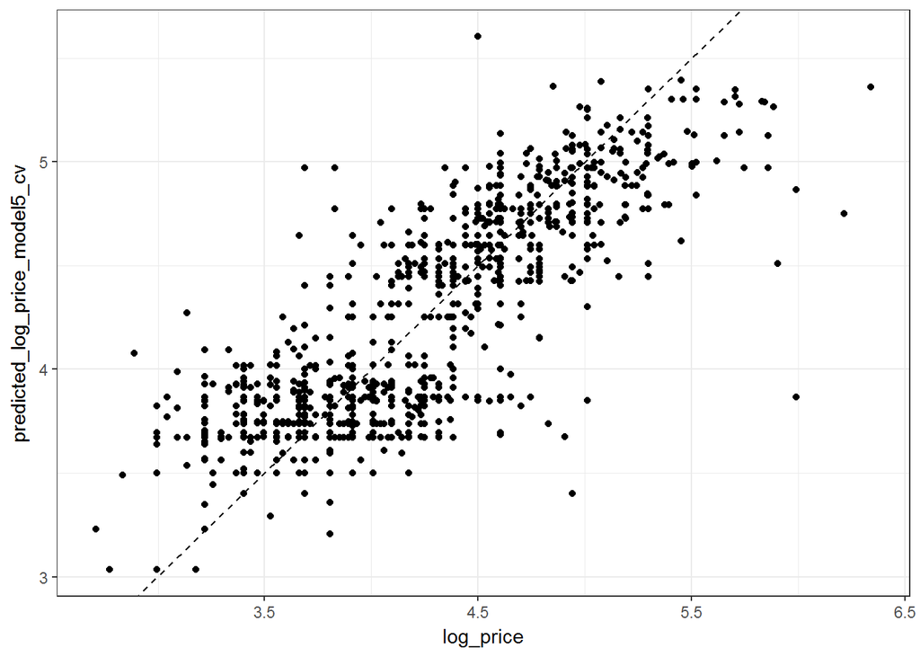

```r
#log price:
ggplot(filtered_data_test, aes(x=log_price, y=predicted_log_price_model5_cv)) + geom_point() + geom_abline(slope = 1, linetype = 2)
```

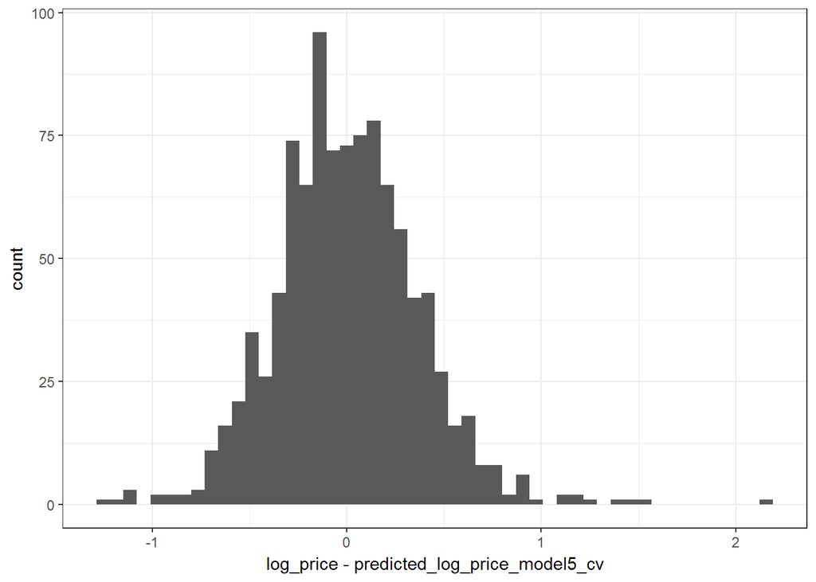

```r
ggplot(filtered_data_test, aes(log_price-predicted_log_price_model5_cv)) + geom_histogram(bins = 50)
```

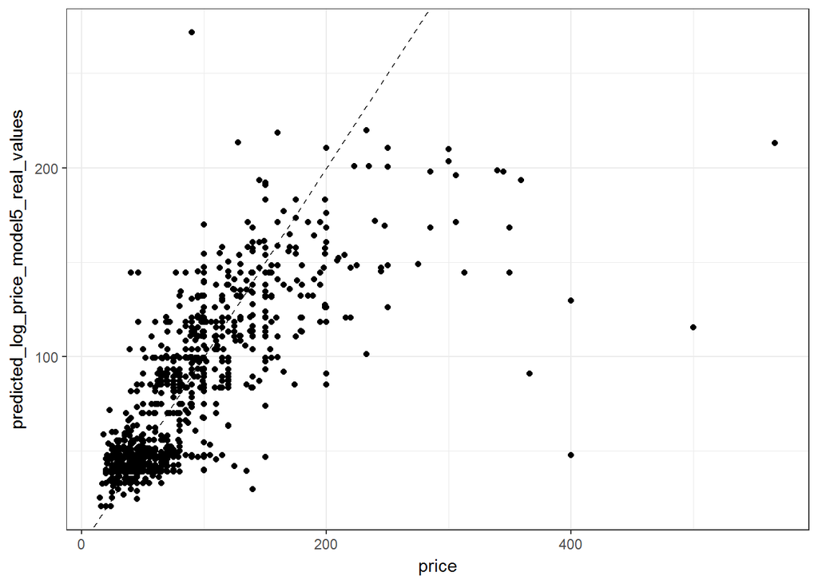

```r
#level price with correction term:
ggplot(filtered_data_test, aes(x=price, y=predicted_log_price_model5_real_values)) + geom_point() + geom_abline(slope = 1, linetype = 2)
```

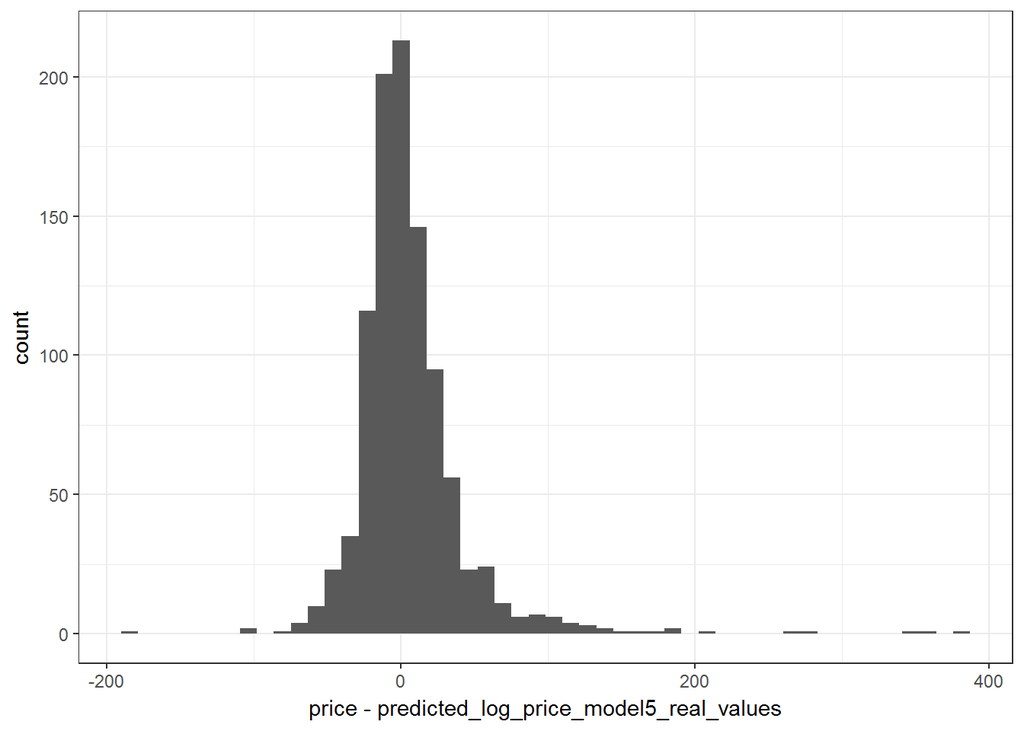

```r
ggplot(filtered_data_test, aes(price-predicted_log_price_model5_real_values)) + geom_histogram(bins = 50)
```

Predictions for a full London:

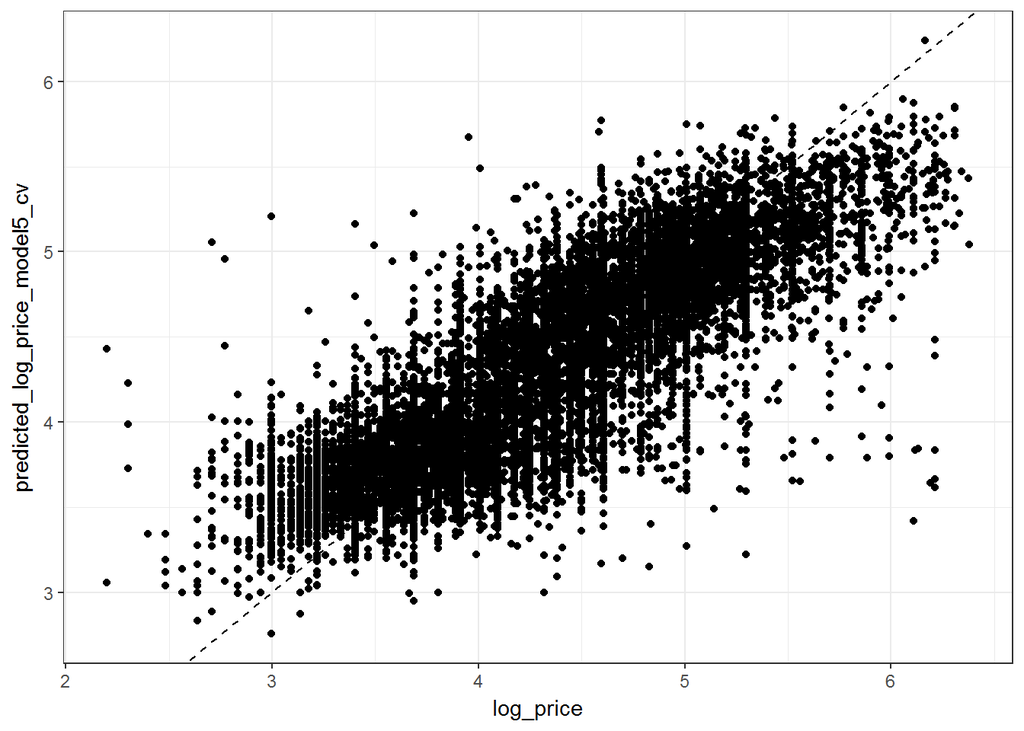

```r
#log price:
ggplot(data_test, aes(x=log_price, y=predicted_log_price_model5_cv)) + geom_point() + geom_abline(slope = 1, linetype = 2)
```

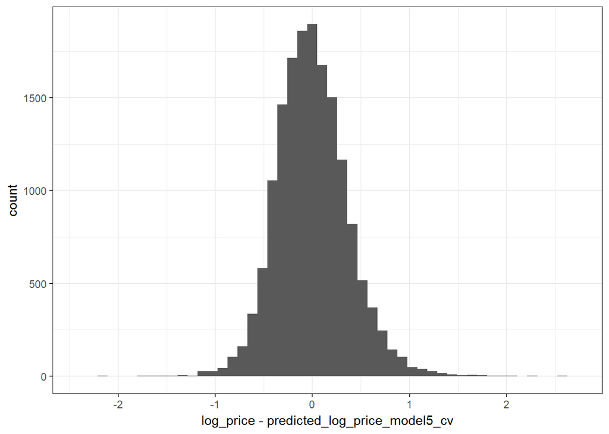

```r
ggplot(data_test, aes(log_price-predicted_log_price_model5_cv)) + geom_histogram(bins = 50)
```

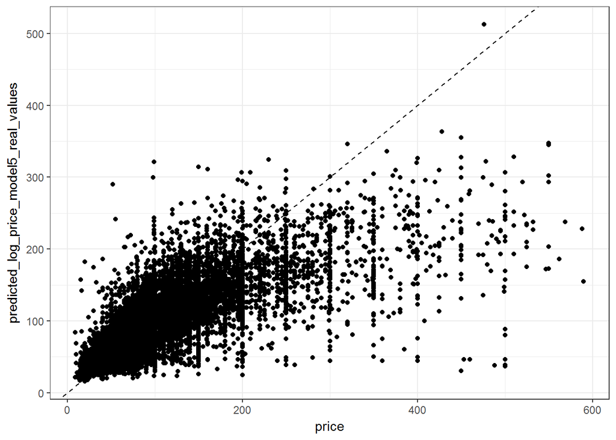

```r
#level price with correction term:
ggplot(data_test, aes(x=price, y=predicted_log_price_model5_real_values)) + geom_point() + geom_abline(slope = 1, linetype = 2)
```

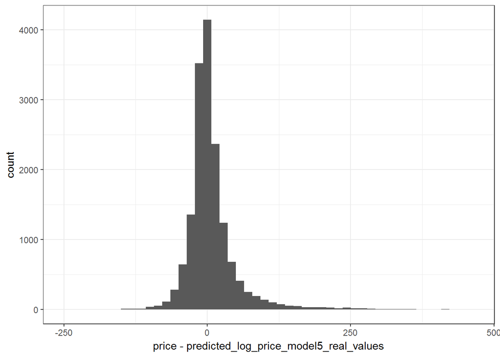

```r
ggplot(data_test, aes(price-predicted_log_price_model5_real_values)) + geom_histogram(bins = 50)
```

**At the end I try to create the best model with interactions for the full London dataset:**

```r
lm_model_full_lasso_cv_final <- train(log_price ~ as.factor(neighbourhood_cleansed) * (poly(accommodates,2) + as.factor(room_type) + as.factor(location_score_above_9) + as.factor(security_deposit_factor) + bathrooms + as.factor(host_is_superhost)),
                  data = data_train,
                  method = "glmnet",
                  trControl = trainControl(method = "cv", number = 10),
                  #preProcess = c("center", "scale"),
                  tuneGrid = expand.grid("alpha" = c(1),"lambda" = c(0.1, 0.01, 0.001, 0.0001)))

#predict prices on the test set of full London:
data_test$predicted_final_model_log <- predict.train(lm_model_full_lasso_cv_final, newdata = data_test)

RMSE_final_log <- RMSE(data_test$predicted_final_model_log, data_test$log_price)
RMSE_final_real <- RMSE(exp(data_test$predicted_final_model_log + 0.1), data_test$price)
```

RMSE of The final model Log:

```r
RMSE_final_log
```

```
## [1] 0.3716268
```

RMSE of the final model if I convert back the log values to level values and using correction term:

```r
RMSE_final_real
```

```
## [1] 45.10487
```

## SUMMARY TABLES, SUMMARY:

To be clear I summarize my findings in the following two tables. I collected all my models RMSEs which was evaluated on the Test set for both a given neighborhood and for full London.

**For a given neighborhood my models give the following RMSEs:**

```r
final_table1 <- data.table(Models = c("model1", "model2", "model3", "model4", "model5_lasso"), `Using Log Prices:` = c(" "), `RMSE without CV` = c(model1_RMSE, model2_RMSE, model3_RMSE, model4_RMSE, model5_RMSE), `RMSE with CV` = c(model1_RMSE_cv, model2_RMSE_cv, model3_RMSE_cv, model4_RMSE_cv, model5_RMSE_cv), `Converted Level Prices:` = c(" "), `RMSE with CV without correction term` = c(RMSE1_real, RMSE2_real, RMSE3_real, RMSE4_real, RMSE5_real), `RMSE with CV with correction term` = c(RMSE1_real_correction, RMSE2_real_correction, RMSE3_real_correction, RMSE4_real_correction, RMSE5_real_correction))

kable(final_table1, align = 'c', digits = 3)
```

| Models | Using Log Prices: | RMSE without CV | RMSE with CV | Converted Level Prices: | RMSE with CV without correction term | RMSE with CV with correction term |
| --- | --- | --- | --- | --- | --- | --- |
| model1 |  | 0.438 | 0.438 |  | 45.261 | 44.395 |
| model2 |  | 0.376 | 0.376 |  | 42.543 | 41.758 |
| model3 |  | 0.366 | 0.366 |  | 41.209 | 40.638 |
| model4 |  | 0.365 | 0.365 |  | 40.292 | 39.820 |
| model5_lasso |  | 0.408 | 0.365 |  | 40.331 | 39.796 |

Which model I would choose? I would choose the 4th model which gives almost the same RMSE as the 5th LASSO model. I do not think using LASSO has a lots of effect in this case and interpretation of the 4th model is easier for an outsider.

Also, for predictions I think the 4th model is the one which I would choose, where I converted back my log_predictions for level using a correction term.

**For entire London my models give the following RMSEs:**

```r
final_table2 <- data.table(Models = c("model1", "model2", "model3", "model4", "model5_lasso", "+final model"), `Using Log Price:` = c(" "), `RMSE without CV` = c(model1_RMSE_full, model2_RMSE_full, model3_RMSE_full, model4_RMSE_full, model5_RMSE_cv_full, NA), `RMSE with CV` = c(model1_RMSE_cv_full, model2_RMSE_cv_full, model3_RMSE_cv_full, model4_RMSE_cv_full, model5_RMSE_cv_full, RMSE_final_log), `Converted Level Prices:` = c(" "), `RMSE with CV without correction term` = c(RMSE1_real_all, RMSE2_real_all, RMSE3_real_all, RMSE4_real_all, RMSE5_real_all, NA), `RMSE with CV with correction term` = c(RMSE1_real_all_correction, RMSE2_real_all_correction, RMSE3_real_all_correction, RMSE4_real_all_correction, RMSE5_real_all_correction, RMSE_final_real))

kable(final_table2, align = 'c', digits = 3)
```

| Models | Using Log Price: | RMSE without CV | RMSE with CV | Converted Level Prices: | RMSE with CV without correction term | RMSE with CV with correction term |
| --- | --- | --- | --- | --- | --- | --- |
| model1 |  | 0.447 | 0.447 |  | 52.078 | 51.412 |
| model2 |  | 0.390 | 0.390 |  | 49.267 | 48.456 |
| model3 |  | 0.380 | 0.380 |  | 48.184 | 47.398 |
| model4 |  | 0.375 | 0.375 |  | 46.208 | 45.374 |
| model5_lasso |  | 0.375 | 0.375 |  | 46.224 | 45.376 |
| +final model |  | NA | 0.372 |  | NA | 45.105 |

Which model I would choose? Same as previously. I would choose the 4th model which gives almost the same RMSE as the 5th LASSO model. I do not think using LASSO has a lots of effect in this case and interpretation of the 4th model is easier for an outsider.

BUT if I would like to give the best predictions I would choose the final model where I introduced interactions. It helps a bit but not too much, but resulting a more accurate price prediction based on the RMSE.

Also, for predictions I think the 4th model is the one which I would choose, where I converted back my log_predictions for level using a correction term.

## EXTRA EXERCISE: TASK 2

**Regression Tree on the given neighborhood**

```r
set.seed(1234)

tune_grid <- data.frame("cp" = c(0.0001, 0.001, 0.01, 0.1, 0.2, 0.3, 0.002, 0.003, 0.005, 0.00001, 0.000001))

rpart_model_n <- train(price ~ accommodates + as.factor(room_type) + as.factor(location_score_above_9) + as.factor(security_deposit_factor) + bathrooms + as.factor(host_is_superhost),
                   data = filtered_data_train,
                   method = "rpart",
                   trControl = trainControl(method = "cv", number = 10),
                   tuneGrid = tune_grid)

rpart_model_n
```

```
## CART
##
## 2338 samples
##    6 predictor
##
## No pre-processing
## Resampling: Cross-Validated (10 fold)
## Summary of sample sizes: 2105, 2104, 2104, 2103, 2104, 2105, ...
## Resampling results across tuning parameters:
##
##   cp     RMSE      Rsquared   MAE
##   1e-06  40.37996  0.5631483  25.20092
##   1e-05  40.38756  0.5629705  25.20627
##   1e-04  40.44332  0.5616888  25.26542
##   1e-03  40.54702  0.5588532  25.30284
##   2e-03  40.48620  0.5598903  25.35083
##   3e-03  41.29809  0.5431204  25.84197
##   5e-03  41.79939  0.5301174  26.17261
##   1e-02  42.19051  0.5211498  26.40077
##   1e-01  48.68260  0.3589272  32.79456
##   2e-01  49.13818  0.3465402  33.13031
##   3e-01  49.13818  0.3465402  33.13031
##
## RMSE was used to select the optimal model using the smallest value.
## The final value used for the model was cp = 1e-06.
```

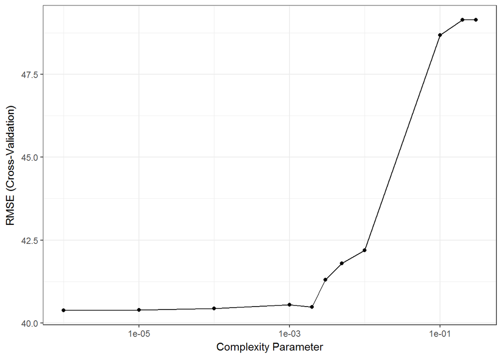

```r
ggplot(rpart_model_n) + scale_x_log10()
```

This is the best plot that I can do, due to the fact that it is so complex.

[figure not shown]

```r
fancyRpartPlot(rpart_model_n$finalModel, main = "Large tree of a given Neighbourhood", sub = " ", tweak=3, type = 2)
```

**Regression tree on full London**

```r
tune_grid <- data.frame("cp" = c(0.0001, 0.001, 0.01, 0.1, 0.2, 0.3, 0.002, 0.003, 0.005, 0.00001, 0.000001))

rpart_model_l <- train(price ~ accommodates + as.factor(neighbourhood_cleansed) + as.factor(room_type) + as.factor(location_score_above_9) + as.factor(security_deposit_factor) + bathrooms + as.factor(host_is_superhost),
                   data = data_train,
                   method = "rpart",
                   trControl = trainControl(method = "cv", number = 10),
                   tuneGrid = tune_grid)

rpart_model_l
```

```
## CART
##
## 37378 samples
##     7 predictor
##
## No pre-processing
## Resampling: Cross-Validated (10 fold)
## Summary of sample sizes: 33640, 33640, 33641, 33640, 33640, 33641, ...
## Resampling results across tuning parameters:
##
##   cp     RMSE      Rsquared   MAE
##   1e-06  45.42201  0.6112269  27.61112
##   1e-05  45.44886  0.6106865  27.62774
##   1e-04  45.32943  0.6119960  27.74133
##   1e-03  46.35575  0.5937660  28.75288
##   2e-03  47.14417  0.5797016  29.44499
##   3e-03  47.82662  0.5675098  30.09951
##   5e-03  48.55981  0.5541430  30.50544
##   1e-02  50.41688  0.5192840  31.82208
##   1e-01  59.39557  0.3328092  39.44224
##   2e-01  59.39557  0.3328092  39.44224
##   3e-01  59.39557  0.3328092  39.44224
##
## RMSE was used to select the optimal model using the smallest value.
## The final value used for the model was cp = 1e-04.
```

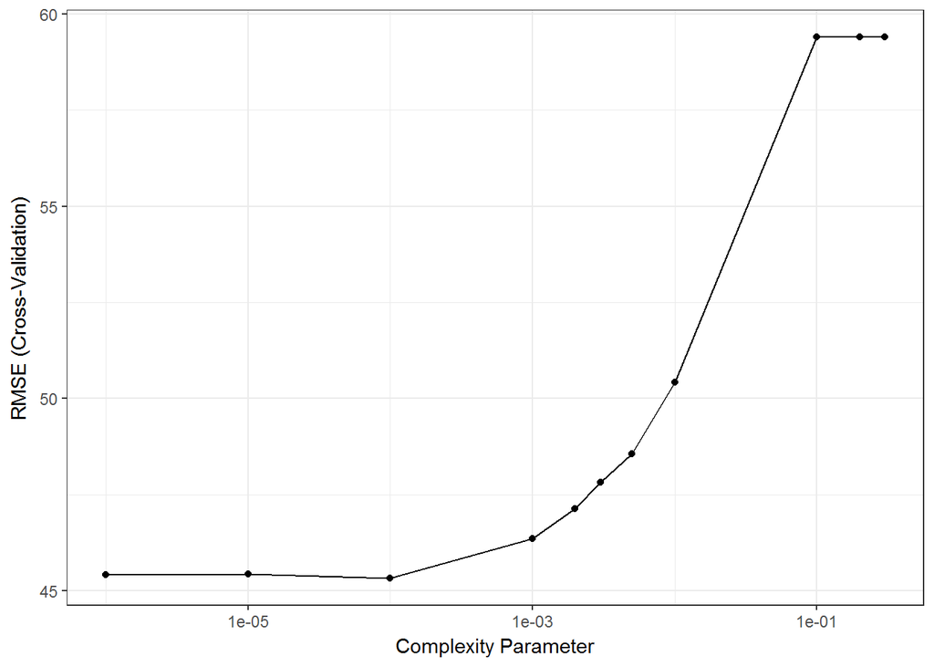

```r
ggplot(rpart_model_l) + scale_x_log10()
```

The tree is too complex for plotting therefore I do not plot it.

**Random Forest on the given neighborhood**

```r
rf_model_n<-train(price ~ accommodates + as.factor(room_type) + as.factor(location_score_above_9) + as.factor(security_deposit_factor) + bathrooms + as.factor(host_is_superhost),
                data=filtered_data_train,
                method="rf",
                trControl=trainControl(method="cv",number=5),
                prox=TRUE,
                allowParallel=TRUE,
                importance=TRUE,
                ntree = 250)
rf_model_n
```

```
## Random Forest
##
## 2338 samples
##    6 predictor
##
## No pre-processing
## Resampling: Cross-Validated (5 fold)
## Summary of sample sizes: 1871, 1870, 1870, 1870, 1871
## Resampling results across tuning parameters:
##
##   mtry  RMSE      Rsquared   MAE
##   2     40.23724  0.5735950  25.24264
##   5     40.72085  0.5551344  25.12628
##   9     41.53088  0.5403570  25.55123
##
## RMSE was used to select the optimal model using the smallest value.
## The final value used for the model was mtry = 2.
```

```r
rf_model_n$finalModel
```

```
##
## Call:
##  randomForest(x = x, y = y, ntree = 250, mtry = param$mtry, importance = TRUE,      proximity = TRUE, allowParallel = TRUE)
##                Type of random forest: regression
##                      Number of trees: 250
## No. of variables tried at each split: 2
##
##           Mean of squared residuals: 1610.766
##                     % Var explained: 56.4
```

Variable importance:

```r
varImp(rf_model_n)
```

```
## rf variable importance
##
##                                                 Overall
## as.factor(room_type)Private room                 100.00
## accommodates                                      73.22
## bathrooms                                         51.54
## as.factor(location_score_above_9)Under_10         49.06
## as.factor(room_type)Shared room                   46.12
## as.factor(security_deposit_factor)not_expensive   37.35
## as.factor(security_deposit_factor)No              34.01
## as.factor(location_score_above_9)Not included     15.72
## as.factor(host_is_superhost)1                      0.00
```

**Random Forest on full London**

Actually my computer is not good enough to train a random forest on the full dataset so I use only a small subset of it:

```r
cut <- createDataPartition(y = data_train$price, times = 1, p = 0.1, list = FALSE)

data_train_small <- data_train[cut, ]

data_train_big <- data_train[-cut, ]
```

```r
rf_model_l<-train(price ~ accommodates + neighbourhood_cleansed + as.factor(room_type) + as.factor(location_score_above_9) + as.factor(security_deposit_factor) + bathrooms + as.factor(host_is_superhost),
                data=data_train_small,
                method="rf",
                trControl=trainControl(method="cv",number=5),
                prox=TRUE,
                allowParallel=TRUE,
                importance=TRUE,
                ntree = 250)
rf_model_l
```

```
## Random Forest
##
## 3739 samples
##    7 predictor
##
## No pre-processing
## Resampling: Cross-Validated (5 fold)
## Summary of sample sizes: 2991, 2992, 2992, 2991, 2990
## Resampling results across tuning parameters:
##
##   mtry  RMSE      Rsquared   MAE
##    2    52.64606  0.5711384  32.92234
##   21    47.42663  0.5776559  29.00430
##   41    48.68779  0.5581213  29.64634
##
## RMSE was used to select the optimal model using the smallest value.
## The final value used for the model was mtry = 21.
```

```r
rf_model_l$finalModel
```

```
##
## Call:
##  randomForest(x = x, y = y, ntree = 250, mtry = param$mtry, importance = TRUE,      proximity = TRUE, allowParallel = TRUE)
##                Type of random forest: regression
##                      Number of trees: 250
## No. of variables tried at each split: 21
##
##           Mean of squared residuals: 2225.972
##                     % Var explained: 58.02
```

Variable importance:

```r
varImp(rf_model_l)
```

```
## rf variable importance
##
##   only 20 most important variables shown (out of 41)
##
##                                                 Overall
## as.factor(room_type)Private room                 100.00
## accommodates                                      88.84
## bathrooms                                         73.64
## neighbourhood_cleansedKensington and Chelsea      48.52
## as.factor(room_type)Shared room                   43.40
## neighbourhood_cleansedWestminster                 37.65
## as.factor(security_deposit_factor)not_expensive   37.51
## as.factor(location_score_above_9)Under_10         34.24
## neighbourhood_cleansedCamden                      31.87
## as.factor(security_deposit_factor)No              31.36
## as.factor(host_is_superhost)1                     25.36
## neighbourhood_cleansedEnfield                     25.24
## neighbourhood_cleansedCity of London              25.15
## neighbourhood_cleansedCroydon                     22.22
## neighbourhood_cleansedTower Hamlets               19.64
## as.factor(location_score_above_9)Not included     19.48
## neighbourhood_cleansedSutton                      19.22
## neighbourhood_cleansedLewisham                    18.43
## neighbourhood_cleansedHammersmith and Fulham      17.54
## neighbourhood_cleansedIslington                   16.04
```

#### Comparing results:

**Predict prices**

```r
#given neighbourhood:
filtered_data_test$tree <- predict.train(rpart_model_n, newdata = filtered_data_test)
filtered_data_test$random_f <- predict.train(rf_model_n, newdata = filtered_data_test)

RMSE_tree <- RMSE(filtered_data_test$tree, filtered_data_test$price)
RMSE_rf <- RMSE(filtered_data_test$random_f, filtered_data_test$price)

#Full London:
data_test$tree <- predict.train(rpart_model_l, newdata = data_test)
data_test$random_f <- predict.train(rf_model_l, newdata = data_test)

RMSE_tree_full <- RMSE(data_test$tree, data_test$price)
RMSE_rf_full <- RMSE(data_test$random_f, data_test$price)
```

**Comparing Regression tree vs. Random Forest vs. the Best Regression models in a given neighborhood**

```r
comparing_table1 <- data.table(Models = c("Regression tree", "Random Forest", "Best Regression"), RMSE = c(RMSE_tree, RMSE_rf, RMSE4_real_correction))

kable(comparing_table1, digits = 3, align = 'c')
```

| Models | RMSE |
| --- | --- |
| Regression tree | 39.659 |
| Random Forest | 40.525 |
| Best Regression | 39.820 |

We can conclude from the table above that all the models are giving almost the same results if we compare their RMSEs on the test set. However the tree model beats the best regression model.

**Comparing Regression tree vs. Random Forest vs. the best Regression in full London**

```r
comparing_table2 <- data.table(Models = c("Regression tree", "Random Forest", "Best Regression"), RMSE = c(RMSE_tree_full, RMSE_rf_full, RMSE5_real_all_correction))

kable(comparing_table2, digits = 3, align = 'c')
```

| Models | RMSE |
| --- | --- |
| Regression tree | 45.368 |
| Random Forest | 47.017 |
| Best Regression | 45.376 |

We can conclude from the table above that all the models are giving almost the same results if we compare their RMSEs on the test set. However the tree model beats the best regression model.